# Breast cancer microbiome recurrence signal implantation benchmark analysis using SIMBA

Mani Arumugam

University of Copenhagen  
arumugam@sund.ku.dk

Date last modified: 16-07-2026

# 1 Overview

This document is a step-by-step walkthrough for reproducing the breast cancer recurrence biomarker detectability and calibration analysis in the manuscript. The analysis starts from a single `phyloseq` object and proceeds through four main stages:

1. prepare the count table and sample metadata;
2. generate signal-implantation simulations with a patched version of SIMBA;
3. benchmark multiple differential abundance methods on the simulated data; and
4. compare the real-data results with simulation-derived detectability boundaries.

The goal is not only to reproduce the figures in the manuscript, but also to make the logic of the workflow transparent to anyone who wants to rerun or adapt it to a comparable dataset.

# 2 Before you start

## 2.1 Required inputs

To reproduce the analysis, you will need:

- a `phyloseq` object containing the taxon count table and sample metadata;
- installation of the patched SIMBA fork from https://github.com/microbiomix/SIMBA
  - (use `devtools::install_github(repo="https://github.com/microbiomix/SIMBA")`)
- the companion helper scripts `helper_functions.R`, `helper_detectability.R`; and
- a writable temporary directory for the HDF5 simulation file and output figures.

## 2.2 What this document assumes

This workflow assumes that the starting `phyloseq` object contains:

- a count-based OTU table;
- a sample-level identifier that can be used as row names for metadata; and
- the clinical variables needed for the benchmarked models.

In the present breast cancer analysis, the main outcome is `Relapse.binary`, and the covariate-adjusted benchmark adjusts for `ki67_ihc`, `bmi_calculated`, `ln_tumorpositive.binary`.

# 3 User configuration

Edit this chunk before running the document. The paths below are examples and should be replaced with the locations on your own system.

```r
# Paths that users should modify -------------------------------------------

# Making sure SIMBA is available

# PREFERRED OPTION:
# Installed via GitHub
# devtools::install_github(repo="https://github.com/microbiomix/SIMBA")
suppressWarnings(library(simbaR))
```

```r
# Alternatively, use a local path to the patched SIMBA fork
# Use this if you have not installed simbaR from github
# Pass this to 'run_method_eval_parallel()' via simba.loc argument
simba.loc <- "/path/to/microbiomix/SIMBA"

# Directory containing helper_functions.R and sensitivity_functions.R
code.loc <- "/path/to/analysis/helpers"

# Writable directory for figure outputs
out.loc <- "/path/to/output/"

# Writable directory for simulation HDF5 files
simh5.loc <- "/path/to/output/"

dir.create(out.loc, recursive = TRUE, showWarnings = FALSE)

# Input phyloseq object
ps_rds <- "/path/to/ps.motus_raw.3.0.3.rds"

# Number of CPUs to use when parallelizing DA test benchmarks
n_cpus <- 8
```

# 4 Load packages and helper functions

The benchmark relies on the patched SIMBA code together with the helper functions used to extract calibration summaries and generate the final figures.

```r
suppressWarnings(library(tidyverse))
suppressWarnings(library(phyloseq))
suppressWarnings(library(dplyr))
suppressWarnings(library(purrr))
suppressWarnings(library(stringr))
suppressWarnings(library(tibble))
suppressWarnings(library(rhdf5))
suppressWarnings(library(ggplot2))
suppressWarnings(library(patchwork))
suppressWarnings(library(ANCOMBC))
suppressWarnings(library(DESeq2))
suppressWarnings(library(edgeR))
suppressWarnings(library(metagenomeSeq))
suppressWarnings(library(LinDA))
suppressWarnings(library(compositions))
suppressWarnings(library(DT))

# Load companion helper functions used throughout the workflow
source(file.path(code.loc, "helper_functions.R"))
source(file.path(code.loc, "helper_detectability.R"))
```

# 5 Load and prepare the phyloseq object

## 5.1 Global analysis settings

These settings define the minimum prevalence filter used throughout the analysis and the significance threshold used in the main benchmark summaries. They also define the number of reps made in the simulation, and how many of them are used for benchmarking.

```r
REPS_MADE <- 50
REPS_USED <- 50
MIN_BENCHMARK_PREVALENCE <- 0.10
MIN_DISCOVERY_PREVALENCE <- 0.10
ALPHA <- 0.10
param_set <- paste("alpha", ALPHA, "prev", MIN_BENCHMARK_PREVALENCE, "reps", REPS_USED, sep = "_")
```

## 5.2 Read the phyloseq object and apply prevalence filtering

We begin from the downloaded `phyloseq` object and remove taxa with prevalence below the chosen threshold.

```r
ps_orig <- readRDS(ps_rds)
ps_orig <- subset_samples(ps_orig, DiseaseStatus.binary == 2 &
                       !is.na(relapse.binary) &
                       !is.na(ln_tumorpositive.binary) &
                       !is.na(ki67_ihc) &
                       !is.na(tumor_size) &
                       !is.na(bmi_calculated))
ps <- filter_taxa_by_prevalence(ps_orig, MIN_BENCHMARK_PREVALENCE)
```

## 5.3 Prepare metadata for SIMBA

SIMBA expects a plain metadata data frame with samples in rows. In this analysis we keep only the variables needed for benchmarking and covariate-adjusted method comparisons.

```r
meta <- sample_data(ps) %>%
  unclass() %>%
  as.data.frame() %>%
  select(participant_id,
         DNA_ID,
         relapse.binary,
         ln_tumorpositive.binary,
         bmi_calculated,
         ki67_ihc,
         tumor_size
         )
meta$Individual_ID <- as.character(meta$participant_id)
meta$participant_id <- NULL
meta$relapse.binary <- as.numeric(meta$relapse.binary)
meta$Timepoint <- 1
rownames(meta) <- meta$DNA_ID
meta$DNA_ID <- NULL

sample_data(ps) <- meta
```

## 5.4 Prepare the count table for SIMBA

The signal implantation framework uses integer counts. We therefore extract the OTU table from `phyloseq`, keep taxa as rows, and round to integer counts.

```r
feat <- otu_table(ps) %>%
  unclass() %>%
  as.data.frame()

rownames(feat) <- taxa_names(ps)
feat[] <- lapply(feat, function(x) as.integer(round(x)))
```

The same workflow can be applied to any metagenomic count table that follows the same basic structure.

```r
feat[1:3, 1:3]
```

```
##                   D1 D100 D102
## ref_mOTU_v3_00085  0    0    0
## ref_mOTU_v3_00095  0 3233    4
## ref_mOTU_v3_00283  0    0    4
```

```r
meta[1:3, 2:4]
```

```
##      ln_tumorpositive.binary bmi_calculated ki67_ihc
## D1                         1       18.50777       10
## D100                       1       24.60937       10
## D102                       0       24.09297       60
```

# 6 Define simulation parameters

We now specify the filtering parameters used internally by SIMBA, the proportion of implanted marker taxa, class balance, subset size, the abundance-shift grid and the number of simulation repeats.

In this benchmark, `ab.scale` is the primary implanted effect-size parameter. We set `prev.scale = 0`, meaning that signals are implanted as abundance differences without additional prevalence shifts.

```r
# SIMBA filtering parameters stored in the HDF5 file
ab.cutoff <- 1e-04
prev.cutoff <- MIN_BENCHMARK_PREVALENCE
log.n0 <- 1e-05

# Simulation design
prop.markers <- 0.1
class.balance <- 15 / 99
subset_size <- 99
sim_reps <- REPS_MADE

# Implanted effect sizes
ab.scale <- seq(1, 10, 0.5)
prev.scale <- 0
```

# 7 Generate the signal-implantation simulations

The patched SIMBA workflow preserves the original sample-to-metadata mapping and allows covariates to remain attached to the same samples during benchmarking. This is crucial when the downstream methods use covariate adjustment.

## 7.1 Create the simulation HDF5 file

Because labels are fixed in this benchmark, we only need one testing-index repetition for each subset size.

```r
force_simulation <- FALSE
param_set1 <- paste("prev", MIN_BENCHMARK_PREVALENCE, "reps", REPS_MADE, sep = "_")
sim.implant <- file.path(simh5.loc, paste0("recurrence_", param_set1, "_implantation.h5"))
if (!file.exists(sim.implant) || force_simulation) {
  set.seed(42)
  file.remove(sim.implant)
  system.time(
    create.data.simulation(
      feat = feat,
      meta = meta,
      sim.location = sim.implant,
      sim.type = "cross-section",
      sim.method = "resampling",
      filt.params = list(
        ab.cutoff = as.numeric(ab.cutoff),
        prev.cutoff = prev.cutoff,
        log.n0 = as.numeric(log.n0)
      ),
      sim.params = list(
        ab.scale = ab.scale,
        prev.scale = prev.scale,
        prop.markers = prop.markers,
        conf = NULL,
        class.balance = class.balance,
        feature.type = "all",
        fixed.labels = TRUE,
        factorize.metadata = FALSE,
        label.col = "relapse.binary",
        case.value = 2,
        control.value = 1,
        repeats = sim_reps
      )
    )
  )
  system.time(
    create.test.idx(
      sim.location = sim.implant,
      subsets = subset_size,
      repetitions = 1,
      fixed.labels = TRUE
    )
  )

}
```

```r
force_simulation <- FALSE

NULL_REPS <- 300
ab.scale <- c(1)
param_set1 <- paste("prev", MIN_BENCHMARK_PREVALENCE, "reps", NULL_REPS, sep = "_")
sim.null <- file.path(simh5.loc, paste0("recurrence_", param_set1, "_null.h5"))
if (!file.exists(sim.null) || force_simulation) {
  set.seed(42)
  file.remove(sim.null)
  system.time(
    create.data.simulation(
      feat = feat,
      meta = meta,
      sim.location = sim.null,
      sim.type = "cross-section",
      sim.method = "resampling",
      filt.params = list(
        ab.cutoff = as.numeric(ab.cutoff),
        prev.cutoff = prev.cutoff,
        log.n0 = as.numeric(log.n0)
      ),
      sim.params = list(
        ab.scale = ab.scale,
        prev.scale = prev.scale,
        prop.markers = prop.markers,
        conf = NULL,
        class.balance = class.balance,
        feature.type = "all",
        fixed.labels = FALSE,
        factorize.metadata = FALSE,
        label.col = "relapse.binary",
        case.value = 2,
        control.value = 1,
        repeats = NULL_REPS
      )
    )
  )
  system.time(
    create.test.idx(
      sim.location = sim.null,
      subsets = subset_size,
      repetitions = 1,
      fixed.labels = FALSE
    )
  )

}
```

```r
temp <- rhdf5::h5ls(sim.implant, recursive = FALSE)
length(setdiff(temp$name, c("original_data", "simulation_parameters")))
```

```
## [1] 950
```

```r
setdiff(temp$name, c("original_data", "simulation_parameters"))[1:10]
```

```
##  [1] "ab10_prev1_rep1"  "ab10_prev1_rep10" "ab10_prev1_rep11" "ab10_prev1_rep12"
##  [5] "ab10_prev1_rep13" "ab10_prev1_rep14" "ab10_prev1_rep15" "ab10_prev1_rep16"
##  [9] "ab10_prev1_rep17" "ab10_prev1_rep18"
```

```r
rm(temp)
```

# 8 Reality check for the simulations

Before running the benchmark, it is useful to verify that the implanted samples still resemble the original data structure. Principal coordinates analysis (PCoA) can be used as a simple visual check.

```r
pcoa.implant <- pcoa.plot(sim.implant, "ab1_prev1_rep1", "bray") +
  labs(title = "Signal implantation")
```

```
## + Checking parameters
```

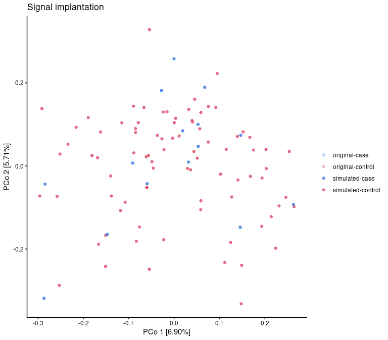

```r
pcoa.implant
```

```r
pcoa.null <- pcoa.plot(sim.null, "ab1_prev1_rep1", "bray") +
  labs(title = "Signal implantation - null")
```

```
## + Checking parameters
```

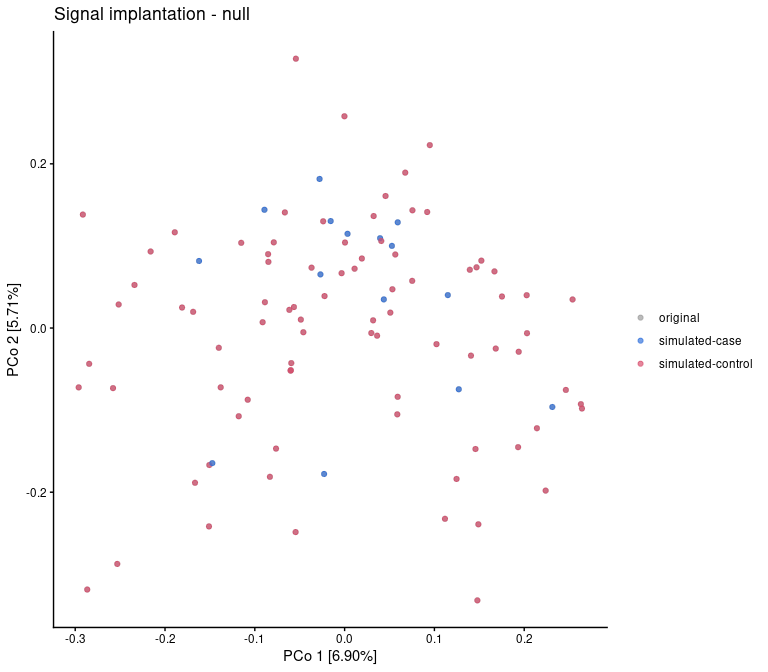

```r
pcoa.null
```

# 9 Prepare the benchmark groups

SIMBA stores one HDF5 group per simulation setting. The chunks below identify all groups and restrict the analysis to the intended number of simulation repeats.

```r
temp <- rhdf5::h5ls(sim.implant, recursive = FALSE)
groups <- setdiff(temp$name, c("original_data", "simulation_parameters"))

# Keep abundance-scale groups with the single prevalence setting used here.
groups.sub <- groups[grepl("^ab[0-9]+_prev1_rep[0-9]+$", groups)]

# Restrict to the requested number of simulation repeats.
groups.sub <- groups.sub[
  as.integer(stringr::str_match(groups.sub, "^ab[0-9]+_prev1_rep([0-9]+)$")[, 2]) <= REPS_USED
]

temp <- rhdf5::h5ls(sim.null, recursive = FALSE)
groups <- setdiff(temp$name, c("original_data", "simulation_parameters"))

# Keep abundance-scale groups with the single prevalence setting used here.
groups.sub.null <- groups[grepl("^ab[0-9]+_prev1_rep[0-9]+$", groups)]

rm(temp, groups)
```

# 10 Benchmark multiple differential abundance methods

The benchmark runs one method at a time across all simulated groups and then aggregates performance metrics across repeats.

## 10.1 Run the implantation-based benchmark

The normalization strategy and covariate adjustment are chosen separately for each method. Calibration tables are also extracted where available, as they are needed later for detectability-boundary analyses.

```r
test_names <- c(
  "LinDA",
  "metagenomeSeq",
  "ANCOMBC2", "ANCOMBC",
  "DESeq2", "lm", "edgeR"
)

force_DA_tests <- FALSE
filename = file.path(simh5.loc, paste0("recurrence_", param_set, "_eval_summary.rds"))
if (!file.exists(filename) || force_DA_tests) {

  # Modify this
  n_workers <- n_cpus

  if (n_workers > 1) {
    future::plan(future::multisession, workers = n_workers)
  } else {
    future::plan("sequential")
  }

  method_results_recurrence <- test_names %>%
    set_names() %>%
    purrr::map(function(test_name) {
      # Method-specific normalization
      norm_method <- dplyr::case_when(
        test_name == "lm" ~ "clr_halfmin",
        test_name == "wilcoxon" ~ "TSS",
        test_name == "LinDA" ~ "TSS",
        TRUE ~ "pass"
      )

      # Covariate adjustment where relevant
      covariates <- NULL
      if (test_name %in% c("LinDA", "metagenomeSeq", "lm", "ANCOMBC", "ANCOMBC2", "DESeq2", "edgeR")) {
        covariates <- c("bmi_calculated", "ki67_ihc", "ln_tumorpositive.binary")
      }

      # Some methods do not currently return effect sizes in the patched workflow
      return_calib <- TRUE

      simbaR::run_method_eval_parallel(
        test_name = test_name,
        groups.sub = groups.sub,
        sim.implant = sim.implant,
        subset_size = subset_size,
        ab.scale = ab.scale,
        alpha = ALPHA,
        norm = norm_method,
        covariates = covariates,
        seed = TRUE,
        show_progress = TRUE,
        simba.loc = NULL,
        return_calib = return_calib
      )
    })
  saveRDS(method_results_recurrence, file = filename)
} else {
  method_results_recurrence <- readRDS(file = filename)
}
```

## 10.2 Summarize benchmark performance

```r
master_evals_recurrence <- dplyr::bind_rows(purrr::map(method_results_recurrence, "evals"))

power_combined_benchmark_recurrence <- master_evals_recurrence %>%
  dplyr::filter(test %in% test_names) %>%
  group_by(test, ab_scale, prev_index) %>%
  summarise(
    mean_power = mean(power, na.rm = TRUE),
    sd_power = sd(power, na.rm = TRUE),
    mean_fdr = mean(empirical_fdr, na.rm = TRUE),
    sd_fdr = sd(empirical_fdr, na.rm = TRUE),
    mean_precision = mean(precision, na.rm = TRUE),
    mean_auroc = mean(auroc, na.rm = TRUE),
    mean_abs_eff_tp2 = mean(mean_abs_eff_tp, na.rm = TRUE),
    sd_abs_eff_tp = sd(mean_abs_eff_tp, na.rm = TRUE),
    mean_abs_eff_marker2 = mean(mean_abs_eff_marker, na.rm = TRUE),
    sd_abs_eff_marker = sd(mean_abs_eff_marker, na.rm = TRUE),
    n_reps = n(),
    .groups = "drop"
  )

datatable(power_combined_benchmark_recurrence)
```

|  | test | ab_scale | prev_index | mean_power | sd_power | mean_fdr | sd_fdr | mean_precision | mean_auroc | mean_abs_eff_tp2 | sd_abs_eff_tp | mean_abs_eff_marker2 | sd_abs_eff_marker | n_reps |
| --- | --- | --- | --- | --- | --- | --- | --- | --- | --- | --- | --- | --- | --- | --- |
| 1 | ANCOMBC | 1 | 1 | 0.001118773946360153 | 0.003390750481201163 | 0.9 | 0.3030457633656632 | 0.1 | 0.5031583302210225 | 0.7891353016460043 | 3.026248844948179e-15 | 0.258208614481678 | 0.02038499345385162 | 50 |
| 2 | ANCOMBC | 1.5 | 1 | 0.005126092384519351 | 0.008479618812778988 | 0.7666666666666667 | 0.3417309546287458 | 0.2133333333333333 | 0.5854228640969175 | 1.058810457867746 | 0.1638402339664891 | 0.3408738036289814 | 0.02737426142649024 | 50 |
| 3 | ANCOMBC | 2 | 1 | 0.04321598002496879 | 0.03156110644591203 | 0.4051566211566212 | 0.1994341354243131 | 0.5548433788433789 | 0.6419806556672254 | 1.281796520904474 | 0.1970495429302066 | 0.4519536260975079 | 0.04488356632913486 | 50 |
| 4 | ANCOMBC | 2.5 | 1 | 0.1042496878901373 | 0.03184351245158892 | 0.2902812801233854 | 0.06202207287714886 | 0.7097187198766146 | 0.6876258839254816 | 1.436906985350984 | 0.1291681402083689 | 0.5530997240041563 | 0.04281712739528858 | 50 |
| 5 | ANCOMBC | 3 | 1 | 0.1577802746566792 | 0.04813464713806702 | 0.2375304289338703 | 0.05717359595989761 | 0.7624695710661297 | 0.7285697149581883 | 1.545273487727773 | 0.1411574147512222 | 0.6521648556560163 | 0.05751395228774274 | 50 |
| 6 | ANCOMBC | 3.5 | 1 | 0.2016479400749064 | 0.05265565207056108 | 0.2273524754787236 | 0.04459540223053968 | 0.7726475245212764 | 0.7503872752223169 | 1.606152200914218 | 0.1189731458820277 | 0.7178275208509385 | 0.06378415824547708 | 50 |
| 7 | ANCOMBC | 4 | 1 | 0.2674214618091023 | 0.05799157311580883 | 0.1986968148278863 | 0.03010029100854289 | 0.8013031851721137 | 0.7519017882177635 | 1.659499995482199 | 0.1572215586915474 | 0.8009657104597728 | 0.07404774394045992 | 50 |
| 8 | ANCOMBC | 4.5 | 1 | 0.2798612529792305 | 0.06045107447160756 | 0.1827479983707638 | 0.03613740968609882 | 0.8172520016292362 | 0.7530568337215808 | 1.73628278414929 | 0.13143119326344 | 0.8346239231394885 | 0.08519935437245242 | 50 |
| 9 | ANCOMBC | 5 | 1 | 0.2992223924639655 | 0.06267204887363645 | 0.191952268462474 | 0.03276886805085766 | 0.8080477315375261 | 0.7636741211385666 | 1.809711183020808 | 0.1153533551119783 | 0.8933126436870299 | 0.08567126511030003 | 50 |
| 10 | ANCOMBC | 5.5 | 1 | 0.3257921915787084 | 0.06228828052326216 | 0.173779944784501 | 0.03060508497678234 | 0.826220055215499 | 0.7829202677198978 | 1.878543759450314 | 0.1255545817160877 | 0.9559359345413906 | 0.0765072344670094 | 50 |

[output cut: 123 more lines]

## 10.3 Visualize benchmark performance

These plots provide the benchmark overview used to select methods for the downstream detectability analyses.

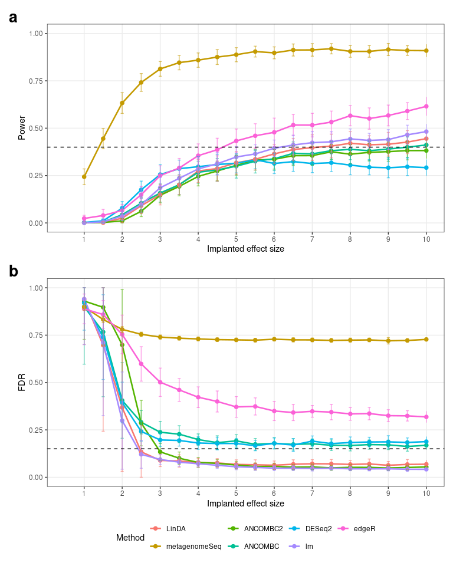

```r
plot_df <- power_combined_benchmark_recurrence %>%
  filter(test %in% test_names) %>%
  mutate(test = factor(test, levels = test_names))

p_fdr <- ggplot(plot_df, aes(x = ab_scale, y = mean_fdr, color = test, group = test)) +
  geom_line(linewidth = 0.9) +
  geom_point(size = 2) +
  geom_errorbar(
    aes(
      ymin = pmax(0, mean_fdr - sd_fdr),
      ymax = pmin(1, mean_fdr + sd_fdr)
    ),
    width = 0.08,
    alpha = 0.6
  ) +
  geom_hline(yintercept = 0.15, linetype = 2) +
  scale_x_continuous(limits = c(0.5, 10), breaks = seq(1, 10)) +
  scale_y_continuous(limits = c(0, 1)) +
  labs(
    x = "Implanted effect size",
    y = "FDR",
    color = "Method"
  ) +
  theme_bw() +
  theme(panel.grid.minor = element_blank())

p_power <- ggplot(plot_df, aes(x = ab_scale, y = mean_power, color = test, group = test)) +
  geom_line(linewidth = 0.9) +
  geom_point(size = 2) +
  geom_errorbar(
    aes(
      ymin = pmax(0, mean_power - sd_power),
      ymax = pmin(1, mean_power + sd_power)
    ),
    width = 0.08,
    alpha = 0.6
  ) +
  geom_hline(yintercept = 0.40, linetype = 2) +
  scale_x_continuous(limits = c(0.5, 10), breaks = seq(1, 10)) +
  scale_y_continuous(limits = c(0, 1)) +
  labs(
    x = "Implanted effect size",
    y = "Power",
    color = "Method"
  ) +
  theme_bw() +
  theme(panel.grid.minor = element_blank())

recurrence_summary_plot <- ((p_power + labs(tag = "a")) / (p_fdr + labs(tag = "b"))) +
  plot_layout(guides = "collect") &
  theme(
    legend.position = "bottom",
    plot.tag = element_text(size = 20, face = "bold")
  )

recurrence_summary_plot
```

```r
ggsave(filename = file.path(out.loc, paste0("recurrence_", param_set, "_summary.pdf")),
       plot = recurrence_summary_plot,
       device = cairo_pdf,
       width = 8,
       height = 10)
ggsave(filename = file.path(out.loc, paste0("recurrence_", param_set, "_power.pdf")), plot = p_power, width = 8, height = 5)
ggsave(filename = file.path(out.loc, paste0("recurrence_", param_set, "_fdr.pdf")), plot = p_fdr, width = 8, height = 5)
```

## 10.4 Build the calibration table

The calibration analysis uses method-specific p-values and effect sizes extracted from the benchmarked simulations.

```r
master_calib_recurrence <- dplyr::bind_rows(purrr::map(method_results_recurrence, "calib_df")) %>%
  mutate(
    detected = as.logical(padj < ALPHA),
    is_tp = as.logical(detected & is_marker),
    is_fp = as.logical(detected & !is_marker)
  )
```

# 11 Select methods for interpretability analysis

Only methods that jointly satisfy the chosen benchmark criteria are carried forward into the detectability-boundary plots. We have relaxed the criteria to be: above 40% power and below 15% FDR.

```r
good_ones <- power_combined_benchmark_recurrence %>%
  filter(mean_power > 0.40 & mean_fdr < 0.15) %>%
  group_by(test) %>%
  filter(rank(ab_scale, ties.method = "first") == 1) %>%
  arrange(ab_scale, test)
datatable(good_ones)
```

|  | test | ab_scale | prev_index | mean_power | sd_power | mean_fdr | sd_fdr | mean_precision | mean_auroc | mean_abs_eff_tp2 | sd_abs_eff_tp | mean_abs_eff_marker2 | sd_abs_eff_marker | n_reps |
| --- | --- | --- | --- | --- | --- | --- | --- | --- | --- | --- | --- | --- | --- | --- |
| 1 | lm | 6.5 | 1 | 0.4113209193836858 | 0.05199045179772031 | 0.0478177066029167 | 0.01304842173932722 | 0.9521822933970833 | 0.8744903651116002 | 1.002060374978902 | 0.08022546924590829 | 0.6344771089286456 | 0.04330020211252589 | 50 |
| 2 | LinDA | 7.5 | 1 | 0.405568280636665 | 0.06187709451718683 | 0.07079818728537912 | 0.02291914405421009 | 0.9292018127146209 | 0.8629015277172979 | 3.198930787562286 | 0.2688136869164809 | 1.910786199552496 | 0.1324596891407111 | 50 |

```r
methods_keep <- sort(good_ones$test)
methods_keep
```

```
## [1] "LinDA" "lm"
```

# 12 Generating background distribution

## 12.1 Label-shuffled simulations of real data for generating background null distribution

```r
test_names <- methods_keep

force_DA_tests <- FALSE
filename = file.path(simh5.loc, paste0("recurrence_", NULL_REPS, "_eval_summary_null.rds"))
if (!file.exists(filename) || force_DA_tests) {

  # Modify this
  n_workers <- n_cpus

  if (n_workers > 1) {
    future::plan(future::multisession, workers = n_workers)
  } else {
    future::plan("sequential")
  }

  method_results_recurrence_null <- test_names %>%
    set_names() %>%
    purrr::map(function(test_name) {
      # Method-specific normalization
      norm_method <- dplyr::case_when(
        test_name == "lm" ~ "clr_halfmin",
        test_name == "wilcoxon" ~ "TSS",
        test_name == "LinDA" ~ "TSS",
        TRUE ~ "pass"
      )

      # Covariate adjustment where relevant
      covariates <- NULL
      if (test_name %in% c("LinDA", "metagenomeSeq", "lm", "ANCOMBC", "ANCOMBC2", "DESeq2", "edgeR")) {
        covariates <- c("bmi_calculated", "ki67_ihc", "ln_tumorpositive.binary")
      }

      # Some methods do not currently return effect sizes in the patched workflow
      return_calib <- TRUE

      simbaR::run_method_eval_parallel(
        test_name = test_name,
        groups.sub = groups.sub.null,
        sim.implant = sim.null,
        subset_size = subset_size,
        ab.scale = ab.scale,
        alpha = ALPHA,
        norm = norm_method,
        covariates = covariates,
        seed = TRUE,
        show_progress = TRUE,
        simba.loc = NULL,
        return_calib = return_calib
      )
    })
  saveRDS(method_results_recurrence_null, file = filename)
} else {
  method_results_recurrence_null <- readRDS(file = filename)
}
```

## 12.2 Build the calibration table for null

```r
master_calib_recurrence_null <- dplyr::bind_rows(purrr::map(method_results_recurrence_null, "calib_df")) %>%
  mutate(
    detected = as.logical(padj < ALPHA),
    is_tp = FALSE,
    is_fp = as.logical(detected)
  )
```

## 12.3 How many times were there false positives from the null simulation?

```r
master_calib_recurrence_null %>%
  dplyr::filter(is_fp, test %in% methods_keep) %>%
  group_by(test) %>%
  summarise(count=n())
```

```
## # A tibble: 2 × 2
##   test  count
##   <chr> <int>
## 1 LinDA   281
## 2 lm      149
```

```r
master_calib_recurrence_null %>%
  dplyr::filter(is_fp, test %in% methods_keep) %>%
  group_by(feature) %>%
  summarise(times_detected=n()) %>%
  filter(times_detected > 0) %>%
  group_by(times_detected) %>%
  summarise(freq=n())
```

```
## # A tibble: 5 × 2
##   times_detected  freq
##            <int> <int>
## 1              1   128
## 2              2    86
## 3              3    27
## 4              4    11
## 5              5     1
```

# 13 Run the real-data differential abundance analyses

The next step is to run the corresponding differential abundance methods on the real breast cancer case/control data. These results are then compared with the simulation-derived detectability boundaries.

```r
# prepare the tables
ps2 <- filter_taxa_by_prevalence(ps, MIN_DISCOVERY_PREVALENCE)
ps2rel <- transform_sample_counts(ps2, function(x) x / sum(x))
real_feat_relab <- as(otu_table(ps2rel), "matrix")
real_feat_relab <- as.data.frame(real_feat_relab[, rownames(meta)])

force_DA_tests <- FALSE

param_set2 <- paste("alpha", ALPHA, "prev", MIN_DISCOVERY_PREVALENCE, "reps", REPS_USED, sep = "_")
filename = file.path(simh5.loc, paste0("recurrence_", param_set2, "_real_data.rds"))

if (!file.exists(filename) || force_DA_tests) {

  # Encode from 1/2 to 0/1

  meta$relapse.binary <- meta$relapse.binary - 1
  sample_data(ps2) <- meta

  # ANCOMBC2
  res_ancombc2 <- ancombc2(
    data = ps2,
    fix_formula = "relapse.binary + bmi_calculated + ki67_ihc + ln_tumorpositive.binary",
    rand_formula = NULL,
    p_adj_method = "fdr",
    prv_cut = MIN_DISCOVERY_PREVALENCE,
    lib_cut = 1000,
    alpha = ALPHA
  )
  # Filter for sensitivity analysis
  res_ancombc2$res <- res_ancombc2$res %>%
    dplyr::mutate(p_relapse.binary = replace(p_relapse.binary, passed_ss_relapse.binary != TRUE, 1))

  # ANCOMBC
  res_ancombc <- ancombc(
    data = ps2,
    formula = "relapse.binary + bmi_calculated + ki67_ihc + ln_tumorpositive.binary",
    p_adj_method = "fdr",
    pseudo = 1,
    prv_cut = MIN_DISCOVERY_PREVALENCE,
    lib_cut = 1000
  )

  # Re-encode from 0/1 to -1/+1
  newlabel <- as.numeric(meta$relapse.binary)
  newlabel[newlabel == 0] <- -1
  # newlabel[newlabel == 1] <- 1
  meta$relapse.binary <- newlabel

  # lm on clr-transformed abundance with a half-minimum pseudocount
  tab_analysis <- as(otu_table(ps2), "matrix")
  pseudo <- min(tab_analysis[tab_analysis > 0]) / 2
  tab_analysis[tab_analysis == 0] <- pseudo
  tab_analysis <- as.data.frame(apply(tab_analysis, 1, compositions::clr))

  fit_one <- function(y, meta) {
    d <- cbind(meta, y = y)
    fit <- stats::lm(y ~ relapse.binary + bmi_calculated + ki67_ihc + ln_tumorpositive.binary, data = d)
    res <- broom.mixed::tidy(fit, effects = "fixed")
    res[res$term == "relapse.binary", ]
  }

  res_lm <- apply(tab_analysis, MARGIN=2, FUN = fit_one, meta = meta) %>%
    bind_rows(.id = "OTU") %>%
    mutate(padj = p.adjust(p.value, method = "fdr"))

  # LinDA on relative abundance

  meta$relapse.binary = factor(meta$relapse.binary, levels=c(-1, 1))
  res_linda <- LinDA::linda(
    real_feat_relab,
    meta,
    formula = "~ relapse.binary + bmi_calculated + ki67_ihc + ln_tumorpositive.binary",
    alpha = ALPHA,
    p.adj.method = "BH",
    type = "proportion"
  )

  # metagenomeSeq

  sample_data(ps2) <- meta # take the version with factors and -1/+1

  m <- phyloseq_to_metagenomeSeq(ps2)
  m2 <- filterData(m, present = nsamples(ps2) * MIN_DISCOVERY_PREVALENCE, depth = 1000)
  p <- cumNormStat(m2)
  m2 <- cumNorm(m2, p = p)
  pd <- pData(m2)

  mod1 <- model.matrix(~ relapse.binary + bmi_calculated + ki67_ihc + ln_tumorpositive.binary, data = pd)
  res1 <- fitZig(m2, mod1, control = zigControl(maxit = 20, verbose = FALSE))
  res_metagenomeSeq <- MRcoefs(res1, number = nrow(res1), adjustMethod = "fdr")

  # Store raw p-values and effect sizes for downstream interpretability analyses
  p_lm_real <- as.numeric(res_lm$p.value)
  eff_lm_real <- as.numeric(res_lm$estimate)
  p_linda_real = res_linda$output$relapse.binary$pvalue
  eff_linda_real = res_linda$output$relapse.binary$log2FoldChange
  p_mgs_real <- res_metagenomeSeq$pvalues
  eff_mgs_real <- res_metagenomeSeq$relapse.binary1
  p_ancombc_real <- res_ancombc$res$p_val$relapse.binary
  eff_ancombc_real <- res_ancombc$res$lfc$relapse.binary
  p_ancombc2_real <- res_ancombc2$res$p_relapse.binary
  eff_ancombc2_real <- res_ancombc2$res$lfc_relapse.binary

  names(p_lm_real) <- rownames(real_feat_relab)
  names(eff_lm_real) <- rownames(real_feat_relab)
  names(p_linda_real) <- rownames(real_feat_relab)
  names(eff_linda_real) <- rownames(real_feat_relab)
  names(p_mgs_real) <- rownames(real_feat_relab)
  names(eff_mgs_real) <- rownames(real_feat_relab)
  names(p_ancombc_real) <- rownames(real_feat_relab)
  names(eff_ancombc_real) <- rownames(real_feat_relab)
  names(p_ancombc2_real) <- res_ancombc2$res$taxon
  names(eff_ancombc2_real) <- res_ancombc2$res$taxon

  real_results_recurrence <- list(
    lm = list(pval = p_lm_real, eff = eff_lm_real),
    LinDA = list(pval = p_linda_real, eff = eff_linda_real),
    ANCOMBC = list(pval = p_ancombc_real, eff = eff_ancombc_real),
    ANCOMBC2 = list(pval = p_ancombc2_real, eff = eff_ancombc2_real),
    metagenomeSeq = list(pval = p_mgs_real, eff = eff_mgs_real)
  )

  saveRDS(real_results_recurrence, file = filename)
} else {
  real_results_recurrence <- readRDS(file = filename)
}
```

# 14 Plot the combined evidence from lm and LinDA

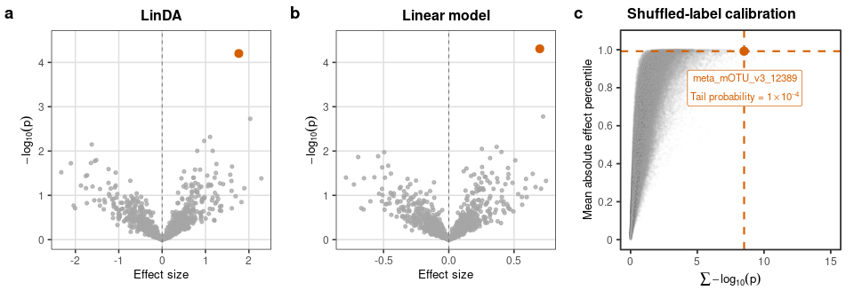

```r
real_prevalence <- rowMeans(feat > 0)

res_bound_abund_recurrence <- run_casecontrol_upper_bound_abundance(
  master_calib = master_calib_recurrence %>% filter(ab_scale > 1),
  feat_real = real_feat_relab,
  methods = methods_keep,
  real_results_list = real_results_recurrence,
  prevalence = real_prevalence,
  target_prob = 0.8,
  adjust = "fdr",
  alpha = ALPHA,
  analysis_subset_col = "is_marker",
  response_col = "detected",
  formula = good_bin ~
        s(effect, k = 4, bs = "ts") +
        s(prevalence, k = 4, bs = "ts") +
        s(abundance, k = 4, bs = "ts")
)

p_linda <- plot_recurrence_volcano(
  real_df = res_bound_abund_recurrence$real_df,
  method = "LinDA",
  candidate_feature = "meta_mOTU_v3_12389",
  title = "LinDA"
) +
  coord_cartesian(ylim = c(0, 4.5)) +
    ggplot2::theme(
    aspect.ratio = 1,
    plot.title = ggplot2::element_text(
      face = "bold",
      size = 12,
      hjust = 0.5
    ),
    axis.title = ggplot2::element_text(size = 10),
    axis.text = ggplot2::element_text(size = 9),
    plot.caption = ggplot2::element_blank()
  )

p_lm <- plot_recurrence_volcano(
  real_df = res_bound_abund_recurrence$real_df,
  method = "lm",
  candidate_feature = "meta_mOTU_v3_12389",
  title = "Linear model"
) +
  coord_cartesian(ylim = c(0, 4.5)) +
    ggplot2::theme(
    aspect.ratio = 1,
    plot.title = ggplot2::element_text(
      face = "bold",
      size = 12,
      hjust = 0.5
    ),
    axis.title = ggplot2::element_text(size = 10),
    axis.text = ggplot2::element_text(size = 9),
    plot.caption = ggplot2::element_blank()
  )

extreme_res <- plot_null_p_effect_extremeness(
  master_calib = master_calib_recurrence_null,
  real_df = res_bound_abund_recurrence$real_df,
  observed_feature = "meta_mOTU_v3_12389",
  methods = c("LinDA", "lm"),
  show_caption = FALSE,
  annotation_dx = 0.05,
  annotation_dy = -0.1,
  annotation_text_size = 3,
  plot_title = NULL
)
p_shuffle <- extreme_res$plot +
  scale_y_continuous(
    limits = c(0, 1.05),
    breaks = seq(0, 1, by = 0.2),
    labels = c("0", "0.2", "0.4", "0.6", "0.8", "1.0")
  ) +
  ggplot2::theme(
    aspect.ratio = 1,
    plot.title = ggplot2::element_text(
      face = "bold",
      size = 12,
      hjust = 0.5
    ),
    axis.title = ggplot2::element_text(size = 10),
    axis.text = ggplot2::element_text(size = 9),
    panel.grid.major = ggplot2::element_blank(),
    panel.grid.minor = ggplot2::element_blank(),
    plot.caption = ggplot2::element_blank()
  ) +
  ggplot2::labs(
    title = "Shuffled-label calibration",
    x = expression(sum(-log[10](p)))
  )

p_recurrence_package <- cowplot::plot_grid(
  p_linda,
  p_lm,
  p_shuffle,
  labels = c("a", "b", "c"),
  label_size = 14,
  label_fontface = "bold",
  nrow = 1,
  align = "hv",
  axis = "tblr",
  rel_widths = c(1, 1, 1)
)

p_recurrence_package
```

```r
ggsave(
  filename = file.path(out.loc, paste0("recurrence_", param_set, "_detected_taxon.pdf")),
  plot = p_recurrence_package,
  device = cairo_pdf,
  width = 10,
  height = 3.5
)
```

# 15 Session information

Session information is printed below to document package versions and the computational environment used for the analysis.

[session information not shown]